# QI vs. Desenvolvimento Econômico: o dinheiro compra inteligência?

André Melo

2025-03-09

## Introdução

A ciência sempre teve um importante papel nas grandes mudanças da história da humanidade. Desde os tempos da Revolução Científica, quando Galileu com seu telescópio, nos fez enxergar o universo de uma nova maneira, até Isaac Newton, que revelou as leis do movimento e da gravidade, o conhecimento sempre impulsionou nossa forma de viver. Hoje, com os avanços da inteligência artificial e muitas outras descobertas, nos mostra essa busca por entender e questionar o mundo, e como ela continua moldando sociedades e transformando nosso futuro.

Nesse avanço destaca-se o Prêmio Nobel, que tem sido uma das mais prestigiadas condecorações científicas do mundo, reconhecendo descobertas e avanços nas áreas de Física, Química, Medicina, Literatura, Paz e, mais recentemente, Economia. Países que acumulam laureados frequentemente são vistos como centros de excelência acadêmica e inovação.

> *Mas será que o progresso científico de um país reflete o nível de inteligência da sua população? Ou fatores como educação, investimento e tradição acadêmica pesam mais do que o QI médio dos habitantes?*

Para responder a essas questões, utilizaremos uma ferramenta fundamental da estatística: o coeficiente de correlação. Essa métrica nos permite medir a força e a direção da relação entre duas variáveis. A base de dados a ser analisada será a *Average global IQ per country with other stats*[^1], que está disponível no *kaggle*. A base apresenta informações sobre o QI médio de 190 países, além de indicadores como desenvolvimento humano (IDH), renda nacional bruta (GNI) e média de anos de escolaridade.

### Pacotes a serem utilizados

```r
library(tidyverse)
library(janitor)
library(ggcorrplot)
```

Caso estes pacotes não estejam instalados, executar comando abaixo.

```r
install.packages("tidyverse")
install.packages("janitor")
install.packages("ggcorrplot")
```

### Importação de dados

Na utilização dos dados, utilizamos o arquivo *avgIQpercountry.csv*[^2]. Além deste, também há o arquivo *iq_classification.csv*, que trata da nomenclatura de nível de QI (ex: Gênio, Dotado, Acima da média, entre outros) com base no intervalo do QI médio dos países. Este último não será abordado neste artigo.

```r
df <- read_csv("dados/avgIQpercountry.csv") |>
  drop_na() |>
  clean_names() |>
  mutate(population_2023 = as.numeric(population_2023))

# Visualizando estrutura dos dados
glimpse(df)
```

```
## Rows: 179
## Columns: 10
## $ rank                         <dbl> 1, 3, 4, 5, 6, 7, 8, 9, 10, 11, 12, 13, 1…
## $ country                      <chr> "Japan", "Singapore", "Hong Kong", "China…
## $ average_iq                   <dbl> 106.48, 105.89, 105.37, 104.10, 102.35, 1…
## $ continent                    <chr> "Asia", "Asia", "Asia", "Asia", "Asia", "…
## $ literacy_rate                <dbl> 0.99, 0.97, 0.94, 0.96, 0.98, 1.00, 1.00,…
## $ nobel_prices                 <dbl> 29, 0, 1, 8, 0, 2, 5, 0, 111, 22, 0, 2, 0…
## $ hdi_2021                     <dbl> 0.925, 0.939, 0.952, 0.768, 0.925, 0.808,…
## $ mean_years_of_schooling_2021 <dbl> 13.4, 11.9, 12.2, 7.6, 12.5, 12.1, 12.9, …
## $ gni_2021                     <dbl> 42274, 90919, 62607, 17504, 44501, 18849,…
## $ population_2023              <dbl> 1.232945e+08, 6.014723e+06, 7.491609e+06,…
```

Removemos os valores *NA’s*, já que estes valores ausentes estão presentes nas variáveis *hdi_2021*, *mean_years_of_schooling_2021* e *gni_2021*. Caso não removidos e seja feita a correlação, os valores *NA’s* implicarão em um resultado *NA*, a menos que seja utilizado o argumento `use = "pairwise.complete.obs"` dentro da função `cov()`.

## QI médio e IDH

Para começar nossa análise, podemos pegar e quantificar a relação entre as variaveis *average_iq* e *hdi_2021*. A correlação é feita através da função `cor()`

```r
cor(df$average_iq, df$hdi_2021)
```

```
## [1] 0.7554595
```

Por meio do resultado, pode-se observar uma correlação positiva forte entre essas variáveis. Mas como posso afirmar que é uma correlação positiva forte? Vejamos

- Se $ r $ for positivo (isto é, $ r $ > 0): existe uma relação direta (quando uma variável aumenta, a outra também tende a aumentar).
- Se $ r $ for negativo (isto é, $ r $ < 0): tem-se uma relação inversa (quando uma variável aumenta, a outra tende a diminuir).
- Se $ r = 0$, então não há correleção entre as variáveis. Ou ainda que o valor esteja muito perto de zero, então esta relação também pode ser dada como inexistente.

A correlação perfeita pode ser atingida quando $ r $ é exatamente 1 (correlação perfeita positiva) ou -1 (correlação perfeita negativa), o que na esmagadora parte das análises, é raro de se ver.

Como vemos no resultado acima, quanto maior o IDH de um país, maior tende a ser o seu QI médio, com base na correlação de 0,755. É importante notar que essa relação não implica causalidade, mas nos dá uma ideia de que melhores condições de vida e acesso à educação podem favorecer o desenvolvimento cognitivo de uma população.

A visualização dos dados ficaria dessa forma:

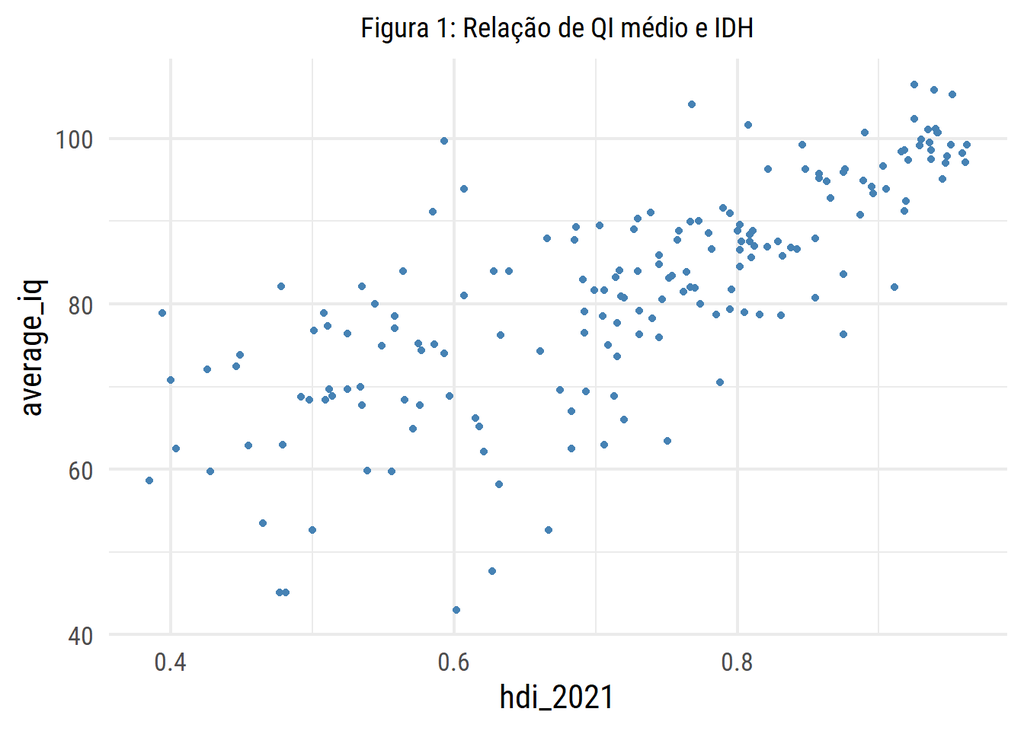

```r
df |>
  ggplot(aes(x = hdi_2021, y = average_iq)) +
  geom_point(col = 'steelblue') +
  theme_minimal()
```

### Tipos de correlação

Por padrão, a função `cor()` utiliza o método de coeficiente de correlação de Pearson, dado pela seguinte fórmula:
$$r = \frac{\sum (X_i - \bar{X}) (Y_i - \bar{Y})}{\sqrt{\sum (X_i -
\bar{X})^2} \cdot \sqrt{\sum (Y_i - \bar{Y})^2}} \tag{1}$$
onde

- $ X_i, Y_i $ são os valores individuais das variáveis $ X $ e $ Y $
- $ {X}, {Y} $ são as médias de $ X $ e $ Y $

O numerado também pode ser representado como $ Cov(X, Y) $ e o numerador como $ S_x $ e $ S_y$, ou seja, a covariância e os desvios padrões das duas variáveis. Nesse contexto, nosso $ X $ seria a variável *average_iq* e $ Y $ seria *hdi_2021*.

Além da correlação de pearson, a função `cor()` também tem-se:

- `cor(x, y, method = "spearman")` mede a correlação baseada em *ranks* (posições) dos valores em vez dos valores absolutos. Caracterizado também por ser uma medida de correlação não-paramétrica.
- `cor(x, y, method = "kendall")` mede a concordância entre as ordens dos valores das variáveis, ou seja, como a ordem entre duas variáveis se mantém (ex: concordantes e discordantes). Por isso, é o método menos afetado por *outliers*.

## Outras variáveis

Na análise de outras variáveis, podemos verificar QI médio e média de anos de escolaridade.

```r
cor(df$average_iq, df$mean_years_of_schooling_2021)
```

```
## [1] 0.7054428
```

Ou alternativamente

```r
cor(df$average_iq, df$gni_2021)
```

```
## [1] 0.6348542
```

Assim, pode-se evidenciar uma forte relação positiva entre QI médio e renda nacional bruta, sugerindo que países mais ricos tendem a ter uma população com maior inteligência média.

No entanto, a correlação com renda nacional bruta (0.635) é menor do que a correlação com IDH (0.755) e anos médios de escolaridade (0.705), o que sugere que educação e qualidade de vida são ainda mais determinantes para o QI médio do que a riqueza de um país em si.

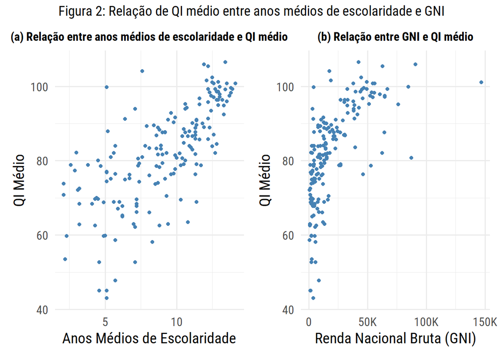

### E como ficam os *outliers*?

Agora que já entendemos as correlações entre QI médio e diferentes indicadores de desenvolvimento, surge uma questão importante: **há países que fogem desse padrão esperado?**

A estatística nos oferece uma maneira bastante objetiva de identificar esses casos. Para isso, podemos recorrer a um critério clássico da análise exploratória de dados: o intervalo interquartil (IQR, *Interquartile Range*). Esse método nos ajuda a determinar pontos de dados que estão muito distantes da maioria, ou seja, possíveis outliers.

No caso, os valores são considerados outliers se estiverem abaixo de:

$$Q1 - 1.5 \times IQR \tag{2}$$

ou acima de:

$$Q3 + 1.5 \times IQR \tag{3}$$

onde

- $ Q1 $ ou primeiro quartil representa o valor abaixo do qual 25% dos dados se encontram;
- $ Q3 $ ou terceiro quartilrepresenta o valor abaixo do qual 75% dos dados se encontram;
- $ IQR $ é a diferença entre $ Q3 $ e $ Q1 $, ou seja, a amplitude interquartil.

Vamos visualizar isso com um exemplo prático no R:

```r
x <- c(-12000, 100, 150, 200, 250, 1000, 5000, 8000, 12000, 40000)

x
```

```
##  [1] -12000    100    150    200    250   1000   5000   8000  12000  40000
```

Visualização dos quartis (ex: Q1, Mediana, Q3, etc.)

```r
quantile(x)
```

```
##       0%      25%      50%      75%     100%
## -12000.0    162.5    625.0   7250.0  40000.0
```

Então, com a visualização dos quartis, podemos calcular o limite inferior e superior para encontrar valores exteriores (isto, que estão acima ou abaixo desses limites), ou como é comumente denominado, *outliers*. É importante destacar que essas observações, apesar de serem discrepantes, podem ou não ser *outliers*.

```r
# Limite superior (Q3 + 1.5 * IQR)
ls <- 7250.0 + 1.5 * IQR(x)

# Limite inferior (Q1 - 1.5 * IQR)
li <- 162.5 - 1.5 * IQR(x)
```

Repare que nosso Q3 é o 75º percentil, assim como Q1 é o 25º percentil. Temos como resultado:

```r
ls
```

```
## [1] 17881.25
```

```r
li
```

```
## [1] -10468.75
```

Qualquer valor acima de 17.881,2 e abaixo de -10468,7 será considerado valores discrepantes, em comparação aos valores adjacentes (isto é, valores que estão compreendidos dentro desses limites). Podemos ver, então, quer -12000 e 40000 seriam considerados valores atípicos, já que estão fora dos limites inferiores e superiores, respectivamente.

**Repare que nosso conjunto de dados *x* é pequeno, como fariamos isso com um volume de dados bem maior, com milhares de observações?**

Para isso, temos a função `boxplot.stats()` que realiza o cálculo que fizemos acima e entrega o *output* em forma de objeto com os valores que ultrapassam os limites. Vamos ver como fica no nosso conjunto de dados *x*.

```r
boxplot.stats(x)$out
```

```
## [1] -12000  40000
```

### Gigantes invisíveis ou viés histórico?

> *A relação entre a população de um país e o número de Prêmios Nobel concedidos a seus habitantes parece intuitiva.* *Quanto mais pessoas, maior a chance de surgir um gênio, certo? Mas os dados contam outra história.*

Imagine um país extremamente populoso, como China (com mais de 1,4 bilhão de habitantes), que tem um QI médio relativamente alto, mas um número de Prêmios Nobel muito inferior ao esperado. Se não considerarmos esse impacto como um *outlier*, a correlação pode não representar bem a maioria dos países.

Da mesma forma, países com um número excepcional de Prêmios Nobel podem distorcer a relação entre inteligência e desenvolvimento acadêmico. Os Estados Unidos, por exemplo, acumulam mais de 400 Prêmios Nobel, muito à frente de qualquer outro país. A Alemanha e o Reino Unido também apresentam números elevados. No entanto, essa métrica não leva em conta a população ou o investimento recente em pesquisa, dificultando comparações justas entre países no contexto da nossa análise. Podemos explorar a relação entre essas duas variáveis, população total (*population_2023*) e prêmio nobel (*nobel_prices*).

```r
cor(df$population_2023, df$nobel_prices)
```

```
## [1] 0.1641867
```

Verificamos uma correlação praticamente inexistente, já que está bem perto de zero. Como próximo passo, aplicamos um método de detecção de outliers para remover os valores extremos dessas variáveis.

```r
# Para a variável população
outliers_varx <- boxplot.stats(df$population_2023)$out

# Para a variável prêmio nobel
outliers_vary <- boxplot.stats(df$nobel_prices)$out
```

E aplicar um filtro para retirar esses valores da base de dados.

```r
df_outlier <- df |>
  filter(!population_2023 %in% outliers_varx & nobel_prices %in% outliers_vary)
```

Deixamos a cargo do leitor para plotar o objeto *df_outlier* em um gráfico de dispersão, semelhante ao que fizemos na Seção 2. (*QI médio e IDH*).

Quando analisamos todos os 179 países, a correlação entre população e Prêmios Nobel foi fraca, apenas 0.16 na Figura (a) abaixo, ou seja, um país grande não necessariamente produz mais laureados. A China e a Índia, por exemplo, têm populações imensas, mas uma modesta quantidade de prêmios, enquanto nações menores, como o Reino Unido e a Alemanha, acumulam vários.

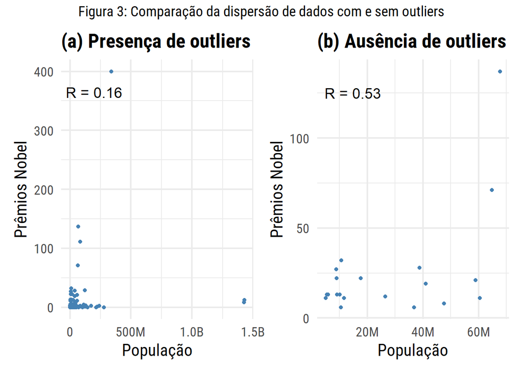

No fim das contas, esse é um exemplo perfeito de como a estatística pode nos fazer ver padrões diferentes dependendo de como tratamos os dados. Como Darrell Huff argumenta em *Como Mentir com Estatística*, os números, por si só, não contam toda a verdade — **é a forma como os apresentamos que molda a narrativa**.

### Outras alternativas

Para evitar o tipo de situação anterior (importante deixar claro que se estivesse realizando uma análise em âmbito global, não faria sentido remover os outliers, além do que, a amostra pode reduzir drasticamente e enviesar a análise).

Como mencionamos anteriormente, há outras formas de calcular o coeficiente de correlação, como por exemplo os métodos de Spearman e Kendall. Se houver outliers ou a relação entre as variáveis não for linear, podemos aplicar o método de Kendall.

```r
cor(df$population_2023, df$nobel_prices, method = "kendall")
```

```
## [1] 0.2895059
```

Antes, ao calcular a correlação pelo método de Pearson, obtivemos 0.16, indicando uma relação muito fraca entre população e Prêmios Nobel. Agora, ao utilizar Kendall, a correlação aumentou para 0.29, o que ainda representa uma relação fraca, mas um pouco mais consistente.

Caso seja de interesse do pesquisador explorar relações com variáveis ordinais, tem-se o método de Spearman, conforme abaixo:

```r
cor(df$rank, df$hdi_2021, method = "spearman")
```

```
## [1] -0.7945742
```

Com a variável *rank*, ou seja, o *ranking* dos países (implica-se em primeiro, segundo, terceiro lugares, e assim por diante). Se o *ranking* mede, por exemplo, a posição do país no ranking de QI médio, um país melhor posicionado (com menor *rank*) geralmente tem um IDH mais alto, o que explica a correlação forte negativa.

### Matriz de correlações

Também podemos gerar uma matriz de correlações, isto é, a relação entre todas as variáveis, em vez de ficar utilizando `cor()` individualmente. Assim como o resultado da função `cor()`, cada célula dessa matriz contém um valor entre -1 e 1 entre uma variável (linha) e outra variável (coluna)

```r
matriz_corr <- df |>
  select(!c(country, continent)) |>
  cor()

matriz_corr
```

```
##                                     rank  average_iq literacy_rate nobel_prices
## rank                          1.00000000 -0.97445416   -0.62353414   -0.2302831
## average_iq                   -0.97445416  1.00000000    0.63343456    0.2144355
## literacy_rate                -0.62353414  0.63343456    1.00000000    0.1254097
## nobel_prices                 -0.23028314  0.21443550    0.12540968    1.0000000
## hdi_2021                     -0.77737636  0.75545950    0.81592944    0.2308959
## mean_years_of_schooling_2021 -0.72746085  0.70544282    0.83199311    0.2339327
## gni_2021                     -0.66128515  0.63485419    0.50170451    0.2692844
## population_2023              -0.04848491  0.07333404   -0.04174697    0.1641867
##                                 hdi_2021 mean_years_of_schooling_2021
## rank                         -0.77737636                  -0.72746085
## average_iq                    0.75545950                   0.70544282
## literacy_rate                 0.81592944                   0.83199311
## nobel_prices                  0.23089587                   0.23393267
## hdi_2021                      1.00000000                   0.91475026
## mean_years_of_schooling_2021  0.91475026                   1.00000000
## gni_2021                      0.78779905                   0.66183364
## population_2023              -0.02836039                  -0.07112675
##                                 gni_2021 population_2023
## rank                         -0.66128515     -0.04848491
## average_iq                    0.63485419      0.07333404
## literacy_rate                 0.50170451     -0.04174697
## nobel_prices                  0.26928442      0.16418671
## hdi_2021                      0.78779905     -0.02836039
## mean_years_of_schooling_2021  0.66183364     -0.07112675
## gni_2021                      1.00000000     -0.05311802
## population_2023              -0.05311802      1.00000000
```

E graficamente, teriamos esta representação:

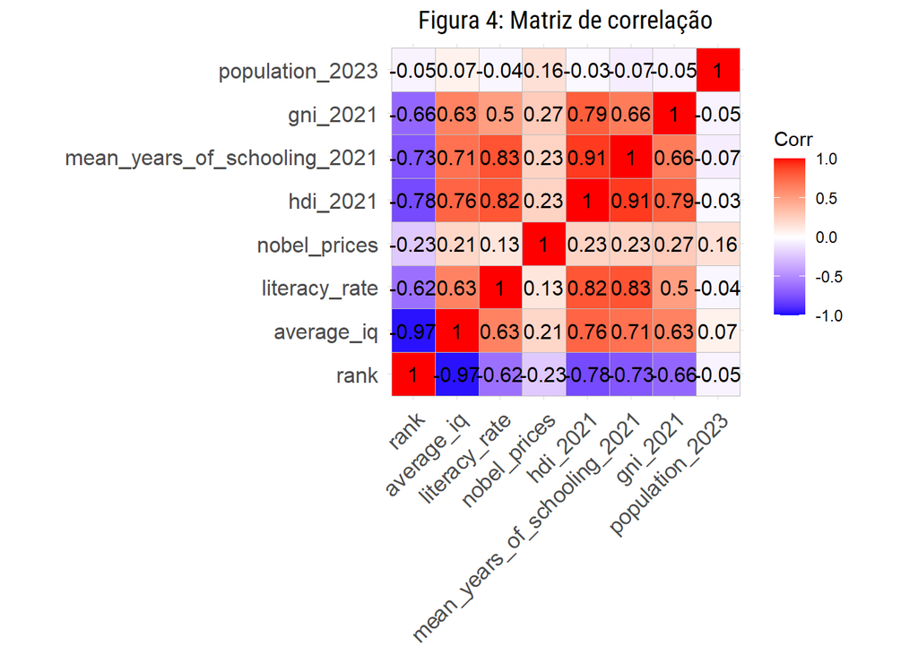

```r
ggcorrplot(matriz_corr, lab = T)
```

Removendo outliers, conseguimos tornar a relação entre população e Prêmios Nobel mais clara, mas ao custo de ignorar os países que mais contribuem para a ciência global. Talvez o verdadeiro fator de influência não seja o tamanho da população, mas o investimento em ciência, a qualidade da educação e o incentivo à pesquisa. Ter milhões de habitantes não basta se não há um ambiente propício para o conhecimento florescer.

[^1]: Os dados podem ser baixados [aqui](https://www.kaggle.com/datasets/mlippo/average-global-iq-per-country-with-other-stats/data?select=iq_classification.csv).
[^2]: Algumas variáveis, como a média dos anos de escolaridade, IDH e GNI são referentes ao anos de 2021, enquanto a população dos países são de 2023.